# Breaking the prejudice habit: Mechanisms, timecourse, and longevity - ScienceDirect

## [Journal of Experimental Social Psychology](https://www-sciencedirect-com.ezproxy.spu.edu/science/journal/00221031)

[Volume 72](https://www-sciencedirect-com.ezproxy.spu.edu/science/journal/00221031/72/supp/C), September 2017, Pages 133-146

# Breaking the prejudice habit: Mechanisms, timecourse, and longevity☆,☆☆,★

[Patrick S.Forscher](https://www-sciencedirect-com.ezproxy.spu.edu/science/article/pii/S0022103116306436#!)[ChelseaMitamura](https://www-sciencedirect-com.ezproxy.spu.edu/science/article/pii/S0022103116306436#!)[Emily L.Dix](https://www-sciencedirect-com.ezproxy.spu.edu/science/article/pii/S0022103116306436#!)[William T.L.Cox](https://www-sciencedirect-com.ezproxy.spu.edu/science/article/pii/S0022103116306436#!)[Patricia G.Devine](https://www-sciencedirect-com.ezproxy.spu.edu/science/article/pii/S0022103116306436#!)

Referred to by

Patrick S. Forscher, Chelsea Mitamura, Emily L. Dix, William T.L. Cox, Patricia G. Devine

[Corrigendum to “Breaking the prejudice habit: Mechanisms, timecourse, and longevity” [Journal of Experimental Social Psychology 72 (2017) 133–146]](https://www-sciencedirect-com.ezproxy.spu.edu/science/article/pii/S0022103117304511)

Journal of Experimental Social Psychology, Volume 73, November 2017, Pages 300

## Abstract

The prejudice habit-breaking intervention (Devine, Forscher, Austin, & Cox, 2012) and its offshoots (e.g., Carnes et al., 2015) have shown promise in effecting long-term change in key outcomes related to intergroup bias, including increases in awareness, concern about discrimination, and, in one study, long-term decreases in implicit bias. This intervention is based on the premise that unintentional bias is like a habit that can be broken with sufficient motivation, awareness, and effort. We conducted replication of the original habit-breaking intervention experiment in a sample more than three times the size of the original (*N* = 292). We also measured all outcomes every other day for 14 days and measured potential mechanisms for the intervention's effects. Consistent with previous results, the habit-breaking intervention produced a change in concern that endured two weeks post-intervention. These effects were associated with increased sensitivity to the biases of others and an increased tendency to label biases as wrong. Contrasting with the original work, both control and intervention participants decreased in implicit bias, and the effects of the habit-breaking intervention on awareness declined in the second week of the study. In a subsample recruited two years later, intervention participants were more likely than control participants to object on a public online forum to an essay endorsing racial stereotyping. Our results suggest that the habit-breaking intervention produces enduring changes in peoples' knowledge of and beliefs about race-related issues, and we argue that these changes are even more important for promoting long-term behavioral change than are changes in implicit bias.

## Keywords

Intervention

Implicit bias

Social cognition

Replication

Intergroup inequality is a ubiquitous problem, with minorities facing disparities in a variety of consequential domains, from the allocation of medical care (Williams, Neighbors, & Jackson, 2003) to hiring (Bertrand & Mullainathan, 2004). One potential contributor to these problems is implicit bias. Theorized to influence behavior despite countervailing intentions (Devine, 1989), implicit bias has attracted attention precisely because it has the potential to cause otherwise fair-minded people to be unwittingly complicit in the perpetuation of inequality. The specter of unintentional discrimination has inspired widespread calls from researchers, scholars, and public policy officials to develop effective interventions to reduce and eliminate the negative effects of unintentional bias (e.g., Fiske, 1998, Smedley et al., 2003). Revealing the scope of the response to this call, a recent meta-analysis uncovered 573 experiments testing methods to change implicit bias (Forscher et al., 2017). Though many interventions reduced implicit bias, very few (6.6% of the meta-analytic samples) have been tested over time. Solving social problems requires interventions that produce changes that endure.

The prejudice habit-breaking intervention contrasts with many of these other interventions in that it was explicitly developed to produce enduring change (Devine et al., 2012; see also Carnes et al., 2015). The habit-breaking intervention is based on the prejudice habit model (Devine, 1989), which proposes that enduring change in biases, such as implicit bias, that occur unintentionally can be achieved by treating unintentional bias as an unwanted habit that can be broken through a combination of motivation, awareness, and effort. This multifaceted intervention was designed to address a number of common stumbling blocks on the path to change. Specifically, although many people feel motivated to overcome biases in their behavior (Devine et al., 1991, Monteith, 1993, Monteith et al., 2002, Plant and Devine, 1998), they are not always aware of their biases (Monteith, Voils, & Ashburn-Nardo, 2001), nor do they always know how to productively channel their motivation into behavior that will help overcome bias (Apfelbaum et al., 2008, Norton et al., 2006). In some cases, the threat of behaving with bias may even lead people to avoid members of minority groups in an effort to prevent the possibility of biased behavior and the negative feelings that follow (Plant and Devine, 2003, Stephan and Stephan, 1985).

Using a semi-interactive slide show, the prejudice habit-breaking intervention navigates people around these stumbling blocks by providing education about the existence, origins, and consequences of unintentional bias, and teaching them evidence-based strategies to overcome bias. This presentation provokes awareness by giving participants feedback about their own level of implicit bias, as measured by the Implicit Association Test (IAT; Greenwald, McGhee, & Schwartz, 1998). The presentation then teaches them how implicit bias can lead to unintentional but consequential discriminatory behavior, leading to negative consequences for racial minorities. Finally, it provides recipients with evidence-based, cognitive strategies that, if practiced, can lead to bias reduction (i.e., stereotype replacement, perspective taking, individuation, counterstereotypic imaging, and increasing opportunities for contact). These strategies give participants productive ways of channeling their behavior into effective solutions that they can implement independently to reduce their bias over time. In a [randomized controlled trial](https://www-sciencedirect-com.ezproxy.spu.edu/topics/neuroscience/randomized-controlled-trial), Devine and colleagues demonstrated that the habit-breaking intervention produced long-term changes in key outcomes, including reduced IAT bias, increased concern about discrimination, and greater reported beliefs that there could be bias present in their thoughts, feelings, and behaviors. These changes endured two months following the intervention.

The long-term effects of the habit-breaking intervention were both exciting and encouraging, suggesting that this intervention might be an effective tool in our efforts to more broadly address sources of persistent social inequality. Before it can fulfill this role, however, we must know how the effects occur, whether they replicate, whether they last longer than two months, and whether they generalize to consequential behaviors. The present work was developed to address these questions. Specifically, we conducted a new experiment to replicate the habit-breaking intervention's effects on implicit bias, concern, and awareness in a larger sample of participants. We further assessed some potential mechanisms of the intervention's effects and examined the extent to which the intervention affected behavior two years later.

With these objectives in mind, we evaluated the effects of the habit-breaking intervention in a two-phase design. In the first phase, we randomly assigned participants to intervention and control conditions and measured a set of outcomes every other day for two weeks. Specifically, every two days, we collected measures of: (1) implicit bias, (2) concern about discrimination, (3) discrepancies between participants' standards for and beliefs about their interracial behavior, and (4) several potential mechanisms for the intervention's effects: the quantity and content of race-related thoughts, race-related conversations, and cross-race interactions with Black people. Participants in the intervention condition were also asked whether and how they used the bias-reduction strategies learned during the intervention. We chose this frequent assessment schedule so that we could obtain stable estimates of the intervention's effects, assess trajectories of change, and assess the relationships between change processes. In the second phase, we invited these same participants to complete an ostensibly unrelated study two years later. Phase 2 contained key measures from Phase 1, as well as three behaviors that could plausibly be affected by the habit-breaking intervention.

## 1. Phase 1

### 1.1. Method

All materials, data, and supplemental analyses are publicly available at https://osf.io/a3c8h/.

#### 1.1.1. Participants

In Phase 1, 302 non-Black students in Introductory Psychology were randomly assigned to intervention (*N* = 138) and control (*N* = 164) conditions. We aimed to obtain a much larger sample size than Devine and colleagues by recruiting as many participants as possible over the course of two semesters. Of the initial 302 participants, four from the control condition were eliminated prior to analysis because they mistakenly received follow-ups designed for the intervention group (referencing the bias-reduction strategies). An additional six participants were eliminated because, on multiple occasions our measure of implicit bias, they had mean reaction times below 400 ms and/or mean accuracies below 70%, suggesting a lack of task attention. These eliminations resulted in a total of 292 participants (136 intervention, 156 control; 68% female, 67% White, 25% Asian) who were eligible for analysis, more than three times the sample of 91 used by Devine et al. (2012).

#### 1.1.2. Procedure

As shown in Fig. 1, our procedure was highly similar to that used by Devine et al. (2012), with six differences that are shown in Table 1 and described in more detail below. At the beginning of the semester, we measured baseline concern and discrepancies between standards and beliefs as part of a large online survey. The online survey also contained measures of attitudes toward Black people and the internal and external motivations for responding without prejudice (IMS and EMS; Plant & Devine, 1998), which we included to ensure equivalence between experimental conditions on these dimensions at baseline. We allowed participants to enroll in the study between two weeks and two months after the completion of the large online survey.

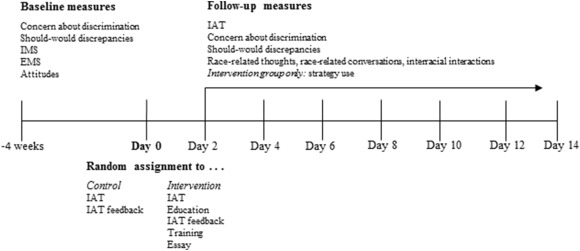

Fig. 1. Study timeline.

Table 1. Differences in procedure between Devine et al. (2012) and the current study.

| **Procedural element** | **Devine et al. (2012)** | **Current study** | **Justification** |
| --- | --- | --- | --- |
| Sequencing of IAT feedback | After IAT and before slideshow | After education section of slideshow | Feedback makes more sense once a person knows about what IAT measures |
| Essay intervention's benefits | Not administered | Administered to intervention participants after slideshow | Enhance intervention's effects through self-persuasion; use as measure |
| Study duration | Two months | Fourteen days | Focus on period soon after intervention |
| Number of follow-ups | Two | Seven | Increase precision; understand timecourse |
| Frequency of follow-ups | Every month | Every other day | Understand changes that occur rapidly |
| Mechanism measures | None | Race-related thoughts & conversations; interracial interactions | Understand mechanisms of intervention |

Participants completed the first session in the lab in groups of one to six. Each group was randomly assigned to condition.<sup>1</sup> All participants were then asked to complete our measure of implicit bias, the Black-White evaluative Implicit Association Test (IAT). After the IAT, control participants received feedback about their IAT scores, completed a measure of affect that is not discussed further, and were dismissed. The IAT feedback and affect measure were included to match the design of Devine et al. (2012), who sought to establish that feedback alone is insufficient to achieve the habit-breaking intervention's effects. Participants in the intervention condition completed the narrated, semi-interactive slideshow that constitutes the prejudice habit-breaking intervention. Embedded in this slideshow was feedback about their IAT score and the same affect measure given to control participants. To encourage participants to pay close attention to the content of intervention, they were told that we were considering adapting the intervention for use with high school students. Ostensibly because “high school students look up to college students,” participants were told that after they viewed the slideshow, they would be asked to write an essay about the possible benefits of the slideshow content for high school students. To help prepare for this essay, intervention participants were given a pen and paper to take notes during the intervention. In the essay, they were allowed to write as little or as much as they wished and were encouraged to cover the major points that were presented during the slideshow. Devine et al. (2012) did not include this essay as a part of the intervention. We added this essay as both a potential measure and because of evidence that self-generated messages can enhance the effect of psychological interventions (Canning & Harackiewicz, 2015; see also Janis and King, 1954, Cialdini et al., 1981). However, adding this essay has the limitation of making this particular instantiation of the habit-breaking intervention less transportable to other contexts. Although we coded the content of the essays, we do not present the coding scheme and results here because there was too little variation in the coding categories for analyses to be meaningful. Nevertheless, the essay coding scheme and results involving the coding categories are presented in full at https://osf.io/a3c8h/.

A link to a follow-up survey was emailed to participants every other evening for two weeks following the in-lab study. Relative to the procedure used by Devine et al. (2012), we shortened the study duration and increased the number and frequency of the follow-ups to obtain a more focused snapshot of the trajectory of change in the study outcomes. We chose a study duration of two weeks and measurement lag of two days to provide a balance between participant burden and measurement frequency. The follow-up survey contained measures of (1) implicit bias, (2) concern about discrimination, (3) discrepancies between standards for and beliefs about one's interracial behavior, and (4) frequencies and content of race-related thoughts, race-related conversations, and interracial interactions involving Black people. Participants assigned to the intervention group also answered questions about each of the five strategies taught during the intervention. They were asked to report how often they used each of the strategies over the past two days using an 8-point scale ranging from “0 times” to “7 or more times”, and to briefly describe a situation in which they used the strategy. If participants missed a survey, they were still encouraged to complete the remaining surveys. Across conditions, participants completed an average of 4.79 (*SD* = 1.75) of the 7 follow-ups. There was no evidence of a differential response rate across conditions (intervention *M* = 4.90, *SD* = 1.64, control *M* = 4.70, *SD* = 1.84, *M*<sub>*diff*</sub> = 0.20, 95% CI = [− 0.21, 0.60].

#### 1.1.3. Implicit Association Test and feedback

We measured implicit bias using the Black-White evaluative IAT (Greenwald et al., 1998). The IAT is a dual categorization task in which people categorize sequentially presented stimuli. In the Black-White evaluative IAT, the participants categorize pictures of Black and White people and pleasant and unpleasant words as to their race and valence, respectively. The assumption underlying the IAT is that people should perform the task faster when concepts that are associated in memory (i.e., Black people with negative words and White people with positive words) are paired on the same response key (*compatible trials*) than with the reverse pairings (*incompatible trials*). Responses on compatible and incompatible trials are used to compute D-scores (Greenwald, Nosek, & Banaji, 2003), which are scored such that higher numbers indicate a greater association of White with positive and Black with negative than the reverse. Overall, participants showed a moderate baseline pro-White bias (baseline *M* = 0.35, *SD* = 0.34, skew = − 0.50, *r*<sub>split half</sub> = 0.79). Immediately following the IAT, control participants were told their IAT D-scores, along with a short interpretation of the D-score as to whether it indicated a preference for White people, no preference, or a preference for Black people, and whether this preference was strong, moderate, or slight (for more details, see Devine et al., 2012).

#### 1.1.4. Prejudice habit-breaking intervention

Immediately after the IAT, intervention participants completed the prejudice habit-breaking intervention. The habit-breaking intervention is divided into education and training sections. In the education section, the participants learn what implicit bias is, how implicit bias is measured, and the consequences of implicit bias for racial minorities. After the education section, the participants received feedback about their personal level of implicit bias, which was formatted in a way that was identical to the feedback given to the control participants. Whereas Devine et al. (2012) gave all participants their feedback immediately following the administration of the IAT, we reasoned that the feedback would be more meaningful to participants after they learned about the IAT and what it is purported to measure.

In the training section of the intervention, the participants were introduced to the idea that implicit bias can be overcome through a combination of motivation, awareness, and the use of bias-reduction strategies, and they are taught five such strategies. These strategies were identical to the strategies used by Devine et al. (2012), which included stereotype replacement (Monteith, 1993), counter-stereotypic imaging (Blair, Ma, & Lenton, 2001), individuating (Brewer, 1988, Fiske and Neuberg, 1990), perspective taking (Galinsky & Moskowitz, 2000), and increasing opportunities for contact (Pettigrew, 1998, Pettigrew and Tropp, 2006). To enhance the perceived utility of these strategies, immediately after learning about each one, participants were asked to generate examples of how they could use the strategy in their own life (Hulleman & Harackiewicz, 2009). Participants were informed that the strategies could have synergistic effects and that the more they practiced the strategies, the more effective they would be.

#### 1.1.5. Racial attitudes, IMS, and EMS

These measures were only assessed in the large online survey administered prior to the habit-breaking intervention. Racial attitudes were assessed using a feelings thermometer, which asks participants to rate how warmly they feel toward Black people using a 0 (*very cold*) to 100 (*very warm*) scale. The internal and external motivations to respond without prejudice (IMS and EMS; Plant & Devine, 1998) measure the extent to which people respond without prejudice for internal, value-driven reasons or external, normative reasons. They are assessed with five items each using a 1 (*strongly disagree*) to 9 (*strongly agree*) scale. The measures are scored such that higher numbers indicate more positive attitudes (*M* = 76.33, *SD* = 20.27, skew = − 0.84), internal motivation (*M* = 7.31, *SD* = 1.60, skew = − 0.82, *α* = 0.76), and external motivation (*M* = 4.17, *SD* = 1.97, skew = 0.11, *α* = 0.81).

#### 1.1.6. Concern about discrimination

Concern measures the extent to which a person believes discrimination toward Black people is a serious problem in society (Devine et al., 2012). The concern scale is composed of 4 items, each of which asks participants to respond to statements like “I consider racial discrimination to be a serious social problem” using a 1 (*strongly disagree*) to 10 (*strongly agree*) scale. Items are scored such that higher numbers indicate greater concern (baseline *M* = 6.77, *SD* = 1.96, skew = − 0.09, *α* = 0.76).

#### 1.1.7. Discrepancies between standards and beliefs

The discrepancy scale measures the difference between how people believe they *should* act, think, and feel in a variety of race-related situations vs. how they actually *would* act, think, and feel in those same situations (Devine et al., 1991, Monteith and Voils, 1998). The discrepancy scale is divided into separate should and would subscales. In the discrepancy scale developed by Monteith and Voils (1998), each subscale contained 16 items, each of which was measured using a 1 (*strongly disagree*) to 7 (*strongly agree*) scale. We reduced this number to 6 items on the should and would subscales to reduce the scale's total length. The should index is created by averaging the responses on the six should items such that higher scores indicate a greater belief that one should act with bias toward Black people (baseline *M* = 1.65, *SD* = 1.02, skew = 2.13, *α* = 0.88). The would index is created by averaging responses on the six *would* items such that higher scores indicate a greater belief that one would act with bias toward Black people (baseline *M* = 2.45, *SD* = 1.15, skew = 0.76, *α* = 0.84). The discrepancies index is created by subtracting responses on the should index from responses on the would index. Higher scores indicate a greater belief that one would act with more bias than one believes is appropriate (baseline *M* = 0.80, *SD* = 1.18, skew = − 0.40, *α* = 0.76).

#### 1.1.8. Race-related thoughts, race-related conversations, and interracial interactions

In the follow-up questionnaires (but not at baseline), participants were asked to report, since the last follow-up questionnaire, the number of thoughts they had had about Black people or issues related to Black people, the number of conversations with others they had had about Black people or issues related to Black people, and the number of interactions they had had with Black people. The length of time “since the last survey” was variable; although the study was designed to obtain follow-up measurements every other day, not all participants completed every survey. The average latency between surveys was slightly longer than 2 days (*M* = 2.25 days, *SD* = 1.20 days). All questions used an 8-point scale ranging from 0 times to 7 or more times.

After each question, if the participants reported at least one thought, conversation, or interaction, they were asked to describe the situation in one to two sentences. We coded these responses for the content of the race-related thoughts, race-related conversations, and interracial interactions by reading through them to identify common themes, which we used to develop a coding scheme. Two people coded each response, and discrepancies between coders were resolved through discussion. We revised the coding criteria of any variables with interrater reliabilities below 0.70 and two new people coded these responses. The final coding scheme and interrater reliabilities are shown in Table 2.<sup>2</sup> Due to high overlap in the thought and conversation themes, we combined scores on these variables for analysis.

Table 2. Free response coding scheme for the short responses to the race-related thought, race-related conversation, and interracial interaction questions.

| **Free response item** | **Variable** | **Levels** | **Example** | *κ* |
| --- | --- | --- | --- | --- |
| Race-related thoughts; conversations | **Participant bias:** coder decides that participant acted with bias | no = 87% yes = 13% | I was thinking of a joke to say about Black people. [*yes*] | 0.74; 0.66 |
|  | **Other bias:** coder decides that a person other than the participant acted with bias | no = 91% yes = 9% | One of my good friends was giving examples of confirmations of African American stereotypes he sees everyday. [*yes*] | 0.79; 0.82 |
|  | **Societal pattern:** response notes racial pattern in society | no = 82% yes = 18% | I was studying about rights of African American women in the 1960s. [*yes*] | 0.66; 0.66 |
|  | **Current event:** response, mentions current event related to Black people | no = 70% yes = 30% | Talking about Obama being the first Black president [*yes*] | 0.79; 0.77 |
|  | **Labeling:** participants labels something as biased/wrong | no = 81% yes = 19% | I was thinking about this survey and thought that I do some racist things [*yes*] | 0.79; 0.79 |
| Interracial interactions | **Structured:** interaction occurs in structured context (e.g., classroom, work) | no = 68% yes = 32% | I talked to a Black person in my class yesterday. [*yes*] | 0.81 |
|  | **Unfamiliar:** Black interaction partner is unfamiliar (not a friend or family) | no = 80% yes = 20% | I talked to African American customers at work. [*yes*] | 0.78 |
|  | **Quality:** interaction is high quality and/or non-superficial | low = 66% high = 34% | I met many of my boyfriend's friends during a visit to West Point and many of them are Black. They were all really nice. And funny. And loud. I liked them! [*high*] | 0.65 |

## 2. Results

### 2.1. Data analytic plan

The intervention and control groups did not differ on any of the variables at baseline (see Table 3), so it appears that random assignment was successful. We conducted all analyses using mixed effects models using lme4 (Bates, Mächler, Bolker & Walker, 2015) and made all plots using ggplot2 (Wickham, 2009). We used Linear Mixed Effects Models if the outcome was quantitative and Generalized Linear Mixed Effects Models if the outcome was not, and obtained confidence intervals using likelihood profiles. Our use of mixed effects has the advantage of using all available information from each participant, thereby providing a natural framework for handling missing data as long they are either missing completely at random or missing at random (MCAR or MAR; Ibrahim & Molenberghs, 2009). For count outcomes, we used a log link in the Poisson family and included an offset for the number of days since the last measurement to account for variable spacing between measurements. For dichotomous variables, we used a logit link in the binomial family.

Table 3. Characteristics of the intervention and control groups at baseline.

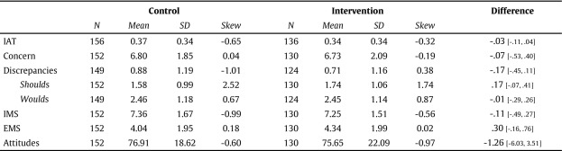

*Note:* The "Difference" column represents the mean difference in the outcome and its 95% CI.

The random effects structure always included a random intercept for each participant. We included random slopes for predictors that varied within participants. When models with random slopes did not converge, we removed the correlation between the intercepts and slopes, which resulted in convergence in all cases. We note in each section when we excluded the correlations between intercepts and slopes.

Unless otherwise noted, all models included as predictors the linear and quadratic effects of time, as well as indicators for condition and the condition by time interactions. When time was included as a predictor, the model also always contained random slopes for time. Time was scaled such that each unit represents one day. Thus, in all analyses of the overall effects of the intervention, the linear effect of time represents the degree to which the outcome of interest changed per day, the quadratic effect of time represents the degree to which the rate of change over time was accelerating or decelerating per day, and the interactions between the time contrasts and condition represents the difference between the intervention and control groups in their rate of change and acceleration/deceleration per day.

Our analyses in Phase 1 address three issues: (1) replication of Devine et al.'s (2012) key findings; (2) examination of people's race-related thoughts, race-related conversations, and interracial interactions; and (3) examination of strategy use.